# 02 — Construcción del dataset integrado

A partir del EDA (`01_EDA.ipynb`) construimos un único dataset con una fila por cada combinación `(idTram, hora)` para el periodo **H2 2021 + 2022** (2021-07-01 → 2022-12-31).

| Bloque | Fuente | Resolución original → horaria |
| --- | --- | --- |
| Tráfico | Itineraris CSV (58 tramos) | ~5 min → media horaria |
| Meteorología | AEMET parquet (3 estaciones) | Horaria nativa (sin expansión) |
| Eventos | FCB + Conciertos + Ferias + Festivales + Agenda cultural | Fecha → flag horario |
| Accidentes | Accidents CSV | Por hora → conteo horario |
| Rasgos temporales | Derivados de `hora` | — |
| Geodatos tramos | `transit_relacio_trams.csv` + itinerarios | Estático (1 fila / tramo) |

**Output:** `../dataset/integrated/dataset_integrado_horario.parquet` **Dimensiones:** 741 182 filas × 55 columnas **Variable objetivo principal:** `sm = tiempo_actual / longitud_tramo_m` (s/m)

## 0. Imports y configuración

```python
import warnings
import os
import glob
from pathlib import Path

import numpy as np
import pandas as pd

warnings.filterwarnings('ignore')
pd.set_option('display.max_columns', 50)
pd.set_option('display.float_format', '{:.4f}'.format)

# Rutas base
DATA_DIR = Path('../dataset')
OUT_DIR  = DATA_DIR / 'integrated'
OUT_DIR.mkdir(parents=True, exist_ok=True)

print('Data dir:', DATA_DIR.resolve())
print('Output dir:', OUT_DIR.resolve())
```

```
Data dir: C:\src\prediccion-trafico-por-evento\dataset
Output dir: C:\src\prediccion-trafico-por-evento\dataset\integrated
```

## 1. Tráfico — carga y agregación horaria

Cargamos todos los CSV de Itineraris disponibles, filtramos al periodo de estudio **H2 2021 + 2022** (2021-07-01 → 2022-12-31), y agregamos a granularidad horaria por tramo. Solo se conservan registros con `infoDisponible = 1` y se sustituyen los valores `-1` por `NaN`.

```python
TRAFICO_GLOB = str(DATA_DIR / 'Itineraris' / '*_ITINERARIS_ITINERARIS.csv')

archivos = sorted(glob.glob(TRAFICO_GLOB))
print(f'Archivos encontrados: {len(archivos)}')

# Columnas de interés
COLS_TRAFICO = ['idTram', 'infoDisponible', 'data',
                'tempsActual', 'tempsPrevist',
                'factorReferenciaActual', 'tendencia']

def cargar_mes_trafico(path: str) -> pd.DataFrame:
    """Carga un CSV mensual de Itineraris y aplica limpieza básica."""
    df = pd.read_csv(path, usecols=COLS_TRAFICO, low_memory=False)
    # Parsear timestamp
    df['timestamp'] = pd.to_datetime(df['data'].astype(str), format='%Y%m%d%H%M%S', errors='coerce')
    df = df.drop(columns='data')
    # Filtrar solo registros con datos disponibles
    df = df[df['infoDisponible'] == 1].copy()
    df = df.drop(columns='infoDisponible')
    # Reemplazar -1 por NaN
    for col in ['tempsActual', 'tempsPrevist', 'factorReferenciaActual', 'tendencia']:
        df[col] = df[col].replace(-1, np.nan)
    return df

# Carga incremental por archivo
chunks = []
for path in archivos:
    try:
        chunks.append(cargar_mes_trafico(path))
    except Exception as e:
        print(f'  ERROR {Path(path).name}: {e}')

trafico_raw = pd.concat(chunks, ignore_index=True)
print(f'\nRegistros cargados (infoDisponible=1): {len(trafico_raw):,}')
print(f'Rango temporal: {trafico_raw.timestamp.min()} → {trafico_raw.timestamp.max()}')
print(f'Trams únicos: {trafico_raw.idTram.nunique()}')
trafico_raw.head(3)
```

```
Archivos encontrados: 18

Registros cargados (infoDisponible=1): 8,819,860
Rango temporal: 2021-07-01 00:05:55 → 2022-12-31 23:55:54
Trams únicos: 58
```

|  | idTram | tempsActual | tempsPrevist | factorReferenciaActual | tendencia | timestamp |
| --- | --- | --- | --- | --- | --- | --- |
| 0 | 1 | 302 | 301 | 1.0000 | 1.0000 | 2021-07-01 00:05:55 |
| 1 | 2 | 256 | 255 | 1.0000 | 1.0000 | 2021-07-01 00:05:55 |
| 2 | 3 | 306 | 305 | 1.0000 | 1.0000 | 2021-07-01 00:05:55 |

> `trafico_raw` contiene **8 819 860 registros** (`infoDisponible = 1`) procedentes de 18 archivos CSV mensuales de Itineraris (periodo H2 2021 + 2022: 2021-07-01 → 2022-12-31, 58 tramos únicos). Los valores `-1` se han sustituido por `NaN`.

```python
# Truncar al periodo de interés: H2 2021 + 2022 (2021-07-01 → 2022-12-31)
trafico_raw = trafico_raw[
    (trafico_raw.timestamp >= '2021-07-01') &
    (trafico_raw.timestamp <  '2023-01-01')
].copy()

# Crear columna de hora (truncada al inicio de la hora)
trafico_raw['hora'] = trafico_raw['timestamp'].dt.floor('h')

# Agregar a granularidad horaria por tram
trafico_horario = (
    trafico_raw
    .groupby(['idTram', 'hora'])
    .agg(
        factor_medio    = ('factorReferenciaActual', 'mean'),
        factor_max      = ('factorReferenciaActual', 'max'),
        factor_min      = ('factorReferenciaActual', 'min'),
        factor_std      = ('factorReferenciaActual', 'std'),
        tiempo_actual   = ('tempsActual',            'mean'),
        tiempo_previsto = ('tempsPrevist',            'mean'),
        tendencia_media = ('tendencia',              'mean'),
        n_mediciones    = ('factorReferenciaActual', 'count'),
    )
    .reset_index()
)

print(f'Periodo cubierto: {trafico_raw.timestamp.min().date()} → {trafico_raw.timestamp.max().date()}')
print(f'Filas dataset tráfico horario: {len(trafico_horario):,}')
print(f'Nulos en factor_medio: {trafico_horario.factor_medio.isna().sum():,}')
trafico_horario.head(3)
```

```
Periodo cubierto: 2021-07-01 → 2022-12-31
Filas dataset tráfico horario: 741,182
Nulos en factor_medio: 111,525
```

|  | idTram | hora | factor_medio | factor_max | factor_min | factor_std | tiempo_actual | tiempo_previsto | tendencia_media | n_mediciones |
| --- | --- | --- | --- | --- | --- | --- | --- | --- | --- | --- |
| 0 | 1 | 2021-07-01 00:00:00 | 1.0000 | 1.0000 | 1.0000 | 0.0000 | 300.4167 | 300.3333 | 1.0000 | 12 |
| 1 | 1 | 2021-07-01 01:00:00 | 1.0000 | 1.0000 | 1.0000 | 0.0000 | 300.0000 | 300.0000 | 1.0000 | 11 |
| 2 | 1 | 2021-07-01 02:00:00 | 1.0000 | 1.0000 | 1.0000 | 0.0000 | 300.0000 | 300.0000 | 1.0000 | 12 |

> `trafico_horario` — **741 182 filas** (58 tramos × ~12 779 horas únicas), filtrado a H2 2021 + 2022. Contiene **111 525 nulos** en `factor_medio` (15,05 %), concentrados en tramos con sensores inactivos. `tiempo_actual` (media de `tempsActual` por hora) es la base para calcular la métrica **s/m** en la fase de integración.

### 1.2 Diagnóstico de fiabilidad de sensores de tráfico

Los sensores de los tramos (Itineraris) pueden fallar de dos maneras principales:

- **Corte total** — el sensor deja de transmitir → aparecen `NaN` en `factor_medio`. Se detecta como porcentaje de nulos > 20 % en un mes × tram.
- **Lecturas anómalas** — el sensor transmite pero los valores no son coherentes con el comportamiento histórico del propio tramo o con sus vecinos del mismo corredor.

Se aplican **dos modelos complementarios** para detectar lecturas anómalas:

1. **Isolation Forest por tramo** — aprende el perfil normal de cada sensor (factor, desviación respecto a su propia media rolling, mediciones, hora del día). Puntúa cada hora según cuánto se aleja del comportamiento habitual del propio tramo. Contamination = 5 %.
2. **Peer comparison por corredor** — para cada hora, compara el factor de un tramo con la media de los otros tramos del mismo itinerario. Si el residuo supera 3σ respecto al error habitual del corredor, se marca como sospechoso. Distingue eventos reales de tráfico (todos los tramos del corredor suben juntos) de fallos de sensor (solo uno diverge).

El flag final `sensor_trafico_ok` (1 = fiable, 0 = sospechoso) se activa si **cualquiera** de las tres señales detecta un problema.

```
Isolation Forest : 30,940 horas anómalas (4.2 %)
Peer comparison  : 1,236 horas anómalas (0.4 %)

Horas sospechosas totales : 154,520 de 741,182 (20.8 %)

Meses con >20% nulos (top 10):
 idTram anyo_mes  null_pct  null_excesivo
      7  2022-10  100.0000           True
     15  2021-09  100.0000           True
     15  2021-08  100.0000           True
     18  2021-08  100.0000           True
     18  2021-07  100.0000           True
     18  2022-06  100.0000           True
     18  2022-05  100.0000           True
     18  2022-04  100.0000           True
     18  2022-03  100.0000           True
     18  2022-02  100.0000           True
```

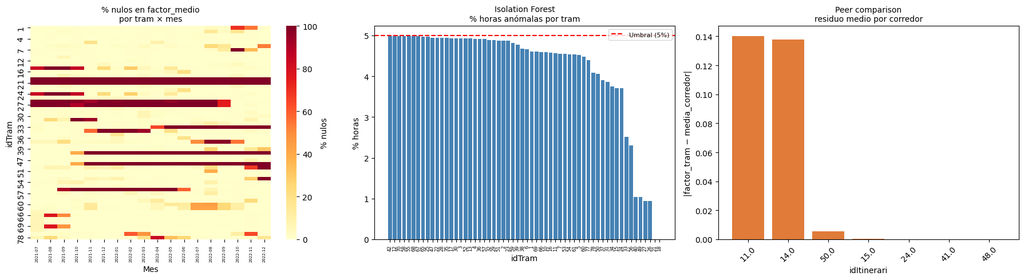

```python
import matplotlib.pyplot as plt
import seaborn as sns
import numpy as np
from sklearn.ensemble import IsolationForest

# ── Parámetros ────────────────────────────────────────────────────────────────
NULL_UMBRAL  = 20    # % nulos en un mes × tram → periodo malo
ROLL_WIN     = 24    # ventana rolling para media propia del tram (horas)
IF_CONTAM    = 0.05  # fracción esperada de anomalías en Isolation Forest
PEER_ZSCORE  = 3.0   # desviaciones sobre el error del corredor → sospechoso

trafico_diag = trafico_horario.copy()
trafico_diag["anyo_mes"]   = trafico_diag["hora"].dt.to_period("M")
trafico_diag["hora_dia"]   = trafico_diag["hora"].dt.hour
trafico_diag["dia_semana"] = trafico_diag["hora"].dt.dayofweek
trafico_diag = trafico_diag.sort_values(["idTram", "hora"]).reset_index(drop=True)

# ── 1. Tasa de nulos por mes × tram ──────────────────────────────────────────
null_tram_mes = (
    trafico_diag.groupby(["idTram", "anyo_mes"])["factor_medio"]
    .apply(lambda g: g.isnull().mean() * 100)
    .round(1)
    .reset_index(name="null_pct")
)
null_tram_mes["null_excesivo"] = null_tram_mes["null_pct"] > NULL_UMBRAL

# ── 2. Isolation Forest por tramo ────────────────────────────────────────────
# Features: desviación del factor respecto a la media rolling propia del tramo,
# n_mediciones y contexto temporal. Evita el falso positivo de std=0 sobre 1.0.
trafico_diag["roll_mean"] = (
    trafico_diag.groupby("idTram")["factor_medio"]
    .transform(lambda s: s.rolling(ROLL_WIN, min_periods=6).mean())
)
trafico_diag["desv_roll"] = (
    (trafico_diag["factor_medio"] - trafico_diag["roll_mean"]).abs()
)

feat_if = ["factor_medio", "desv_roll", "n_mediciones", "hora_dia", "dia_semana"]
trafico_diag["if_anomalia"] = 0

for tram_id, grp in trafico_diag.groupby("idTram"):
    mask_ok = grp[feat_if].notna().all(axis=1)
    if mask_ok.sum() < 50:
        continue
    X = grp.loc[mask_ok, feat_if].fillna(0)
    clf = IsolationForest(contamination=IF_CONTAM, random_state=42, n_jobs=-1)
    preds = clf.fit_predict(X)              # -1 = anomalía, 1 = normal
    trafico_diag.loc[X.index, "if_anomalia"] = (preds == -1).astype(int)

n_if = trafico_diag["if_anomalia"].sum()
print(f"Isolation Forest : {n_if:,} horas anómalas "
      f"({n_if / len(trafico_diag) * 100:.1f} %)")

# ── 3. Peer comparison por corredor ──────────────────────────────────────────
# tram_itinerari se carga aquí para que esta sección sea autónoma respecto a la
# Sección 6, donde se define de forma completa con su markdown asociado.
_tram_it_csv = pd.read_csv(
    DATA_DIR / 'Trams - Itineraris' / 'transit_relacio_tram_per_itinerari.csv',
    encoding='latin-1',
)
_tram_it_csv = _tram_it_csv[_tram_it_csv['Tram'] != 0].copy()
tram_itinerari = _tram_it_csv.rename(columns={'Tram': 'idTram', 'Itinerari': 'idItinerari'})[['idTram', 'idItinerari']].drop_duplicates('idTram')
# Media del corredor = media de los otros tramos del mismo itinerario en esa hora.
# Residuo alto y atípico → sospechoso.
tram_it = (
    trafico_diag[["idTram", "hora", "hora_dia", "factor_medio"]]
    .merge(tram_itinerari[["idTram", "idItinerari"]], on="idTram", how="left")
    .dropna(subset=["idItinerari"])
)

corredor_mean = tram_it.groupby(["idItinerari", "hora"])["factor_medio"].transform("mean")
n_corredor    = tram_it.groupby(["idItinerari", "hora"])["factor_medio"].transform("count")

tram_it["peer_residuo"] = np.where(
    n_corredor >= 2,
    (tram_it["factor_medio"] - corredor_mean).abs(),
    np.nan,
)

# Z-score del residuo dentro de cada (corredor, hora del día)
tram_it["peer_z"] = (
    tram_it.groupby(["idItinerari", "hora_dia"])["peer_residuo"]
    .transform(lambda s: (s - s.mean()) / (s.std() + 1e-9))
)
tram_it["peer_anomalia"] = (tram_it["peer_z"] > PEER_ZSCORE).astype(int)

n_peer = tram_it["peer_anomalia"].sum()
print(f"Peer comparison  : {n_peer:,} horas anómalas "
      f"({n_peer / len(tram_it) * 100:.1f} %)")

# ── 4. Flag final: sensor_trafico_ok ─────────────────────────────────────────
trafico_horario = trafico_horario.copy()
trafico_horario["anyo_mes"] = trafico_horario["hora"].dt.to_period("M")

trafico_horario = trafico_horario.merge(
    null_tram_mes[["idTram", "anyo_mes", "null_excesivo"]],
    on=["idTram", "anyo_mes"], how="left"
)
trafico_horario["null_excesivo"] = trafico_horario["null_excesivo"].fillna(False)

trafico_horario = trafico_horario.merge(
    trafico_diag[["idTram", "hora", "if_anomalia"]],
    on=["idTram", "hora"], how="left"
)
trafico_horario["if_anomalia"] = trafico_horario["if_anomalia"].fillna(0).astype(int)

peer_flags = (
    tram_it[["idTram", "hora", "peer_anomalia"]]
    .drop_duplicates(["idTram", "hora"])
)
trafico_horario = trafico_horario.merge(
    peer_flags, on=["idTram", "hora"], how="left"
)
trafico_horario["peer_anomalia"] = trafico_horario["peer_anomalia"].fillna(0).astype(int)

trafico_horario["sensor_trafico_ok"] = (
    ~trafico_horario["null_excesivo"]
    & (trafico_horario["if_anomalia"]   == 0)
    & (trafico_horario["peer_anomalia"] == 0)
).astype(int)

trafico_horario = trafico_horario.drop(
    columns=["anyo_mes", "null_excesivo", "if_anomalia", "peer_anomalia"]
)

n_malas = (trafico_horario["sensor_trafico_ok"] == 0).sum()
print(f"\nHoras sospechosas totales : {n_malas:,} de {len(trafico_horario):,} "
      f"({n_malas / len(trafico_horario) * 100:.1f} %)")
print(f"\nMeses con >{NULL_UMBRAL}% nulos (top 10):")
print(
    null_tram_mes[null_tram_mes["null_excesivo"]]
    .sort_values("null_pct", ascending=False)
    .head(10)
    .to_string(index=False)
)

# ── 5. Visualización ─────────────────────────────────────────────────────────
fig, axes = plt.subplots(1, 3, figsize=(18, 5))

# Panel 1: Heatmap nulos
pivot_null = (
    null_tram_mes.pivot(index="idTram", columns="anyo_mes", values="null_pct")
    .fillna(0)
)
sns.heatmap(pivot_null, ax=axes[0], cmap="YlOrRd", vmin=0, vmax=100,
            linewidths=0, cbar_kws={"label": "% nulos"})
axes[0].set_title("% nulos en factor_medio\npor tram × mes", fontsize=10)
axes[0].set_xlabel("Mes"); axes[0].set_ylabel("idTram")
axes[0].tick_params(axis="x", rotation=90, labelsize=5)

# Panel 2: Isolation Forest — % anómalas por tram
if_por_tram = (
    trafico_diag.groupby("idTram")["if_anomalia"]
    .mean().mul(100).sort_values(ascending=False)
)
axes[1].bar(if_por_tram.index.astype(str), if_por_tram.values, color="steelblue")
axes[1].axhline(IF_CONTAM * 100, color="red", linestyle="--",
                label=f"Umbral ({IF_CONTAM*100:.0f}%)")
axes[1].set_title("Isolation Forest\n% horas anómalas por tram", fontsize=10)
axes[1].set_xlabel("idTram"); axes[1].set_ylabel("% horas")
axes[1].tick_params(axis="x", rotation=90, labelsize=6)
axes[1].legend(fontsize=8)

# Panel 3: Peer comparison — residuo medio por corredor
peer_by_it = (
    tram_it.dropna(subset=["peer_residuo"])
    .groupby("idItinerari")["peer_residuo"]
    .mean()
    .sort_values(ascending=False)
)
axes[2].bar(peer_by_it.index.astype(str), peer_by_it.values, color="#e07b39")
axes[2].set_title("Peer comparison\nresiduo medio por corredor", fontsize=10)
axes[2].set_xlabel("idItinerari")
axes[2].set_ylabel("|factor_tram − media_corredor|")
axes[2].tick_params(axis="x", rotation=45)

plt.tight_layout()
plt.show()
```

**Panel izquierdo — Heatmap de % nulos por tram × mes**

**Panel central — Isolation Forest: % horas anómalas por tram**

El modelo detecta **30 940 horas anómalas (4,2 %)** sobre el total. La línea roja marca el umbral de contaminación esperada (5 %). La mayoría de tramos se sitúan por debajo; los valores más altos corresponden a tramos con variabilidad alta o con pocos registros.

**Panel derecho — Peer comparison: residuo medio por corredor**

Identifica **1 236 horas adicionales (0,4 %)** donde un tramo se desvía significativamente de sus vecinos de corredor. Los corredores con residuo más alto indican tramos con comportamiento atípico respecto a su itinerario.

**Flag `sensor_trafico_ok`:** combinando los tres criterios se marcan **154 520 horas sospechosas (20,8 %)**. La mayoría proceden del criterio de nulos excesivos (tramos inactivos), no de anomalías en los valores transmitidos.

## 2. Meteorología — datos horarios AEMET

- Ofrece **resolución horaria real** (no requiere expansión diaria → horaria)
- Captura episodios de lluvia matutina sobre la hora punta (granularidad de 1h vs. diaria)
- Añade variables adicionales: dirección del viento, nubosidad y visibilidad

```python
# Cargar datos horarios de AEMET (3 estaciones, resolución horaria nativa)
aemet_raw = pd.read_parquet(DATA_DIR / 'Meteorologia_AEMET' / 'AEMET_horario_2021_2022.parquet')
aemet_raw['fecha'] = pd.to_datetime(aemet_raw['fecha'])

print(f'Registros AEMET: {len(aemet_raw):,}')
print(f'Estaciones: {sorted(aemet_raw["estacion"].unique())}')
print(f'Rango: {aemet_raw.fecha.min()} → {aemet_raw.fecha.max()}')
print('Variables:', [c for c in aemet_raw.columns if c not in ['fecha', 'indicativo', 'estacion']])
aemet_raw.head(3)
```

```
Registros AEMET: 47,666
Estaciones: ['Barcelona_Aeropuerto', 'Barcelona_Drassanes', 'Barcelona_PortOlimpic']
Rango: 2021-01-01 00:00:00 → 2022-12-31 23:00:00
Variables: ['temp_c', 'humedad_pct', 'presion_hpa', 'precipitacion_mm', 'viento_vel_ms', 'viento_dir_grad', 'nubosidad_oktas', 'visibilidad_km']
```

|  | fecha | indicativo | estacion | temp_c | humedad_pct | presion_hpa | precipitacion_mm | viento_vel_ms | viento_dir_grad | nubosidad_oktas | visibilidad_km |
| --- | --- | --- | --- | --- | --- | --- | --- | --- | --- | --- | --- |
| 0 | 2021-01-07 00:00:00 | 0076 | Barcelona_Aeropuerto | 3.3000 | 66.0000 | 1014.7000 | 0.0000 | 5.6000 | 1.0000 | 7.0000 | 2000.0000 |
| 1 | 2021-01-07 01:00:00 | 0076 | Barcelona_Aeropuerto | 3.9000 | 69.0000 | 1014.7000 | 0.0000 | 4.7000 | 1.0000 | 7.0000 | 2000.0000 |
| 2 | 2021-01-07 02:00:00 | 0076 | Barcelona_Aeropuerto | 3.1000 | 71.0000 | 1014.7000 | 0.0000 | 5.0000 | 1.0000 | 7.0000 | 2000.0000 |

> **Nota sobre variables sinópticas:** `presion_hpa`, `nubosidad_oktas` y `visibilidad_km` son observaciones sinópticas del Aeropuerto de Barcelona registradas solo 3–4 veces al día (00h, 07h, 13h, 18h para presión; 07h, 13h, 18h para nubosidad y visibilidad). Las estaciones Drassanes y PortOlímpic no disponen de estas variables (100 % nulos). Se aplica interpolación forward-fill por estación antes del promedio para rellenar las horas intermedias.

```python
# Interpolación temporal de variables sinópticas antes del promedio de estaciones.
# AEMET solo registra presión/nubosidad/visibilidad en observaciones sinópticas
# (4×/día para presión: 00h, 07h, 13h, 18h; 3×/día para nubosidad y visibilidad: 07h, 13h, 18h).
# El forward-fill por estación propaga el último valor observado hasta la siguiente observación.
_SINOPTICAS = {
    'presion_hpa':     7,   # hueco máx entre observaciones = 7 h (18h → 00h siguiente)
    'nubosidad_oktas': 13,  # hueco máx = 13 h (18h → 07h siguiente)
    'visibilidad_km':  13,
}
_aemet = aemet_raw.sort_values(['estacion', 'fecha']).copy()
for _col, _lim in _SINOPTICAS.items():
    _aemet[_col] = (
        _aemet.groupby('estacion')[_col]
        .transform(lambda x: x.ffill(limit=_lim).bfill(limit=_lim))
    )

# Promediar las 3 estaciones AEMET por hora → una fila por timestamp
meteo_horario = (
    _aemet
    .groupby('fecha')[['temp_c', 'humedad_pct', 'presion_hpa', 'precipitacion_mm',
                        'viento_vel_ms', 'viento_dir_grad', 'nubosidad_oktas', 'visibilidad_km']]
    .mean()
    .reset_index()
    .rename(columns={
        'fecha':        'hora',
        'temp_c':       'temp_media_c',
        'humedad_pct':  'humedad_rel_pct',
    })
)

# Flag lluvia (precipitación > 0.2 mm)
meteo_horario['lluvia'] = (meteo_horario['precipitacion_mm'] > 0.2).astype(int)

# Restricción temporal H2 2021 + 2022
meteo_horario = meteo_horario[
    (meteo_horario['hora'] >= '2021-07-01') &
    (meteo_horario['hora'] <  '2023-01-01')
].copy()

print(f'Horas con datos meteo: {len(meteo_horario):,}')
print('Nulos (%) tras interpolación sinóptica:')
for col in ['presion_hpa', 'nubosidad_oktas', 'visibilidad_km',
            'temp_media_c', 'humedad_rel_pct', 'precipitacion_mm']:
    pct = meteo_horario[col].isnull().mean() * 100
    print(f'  {col:25s}: {pct:.2f} %')
meteo_horario.head(3)
```

```
Horas con datos meteo: 13,176
Nulos (%) tras interpolación sinóptica:
  presion_hpa              : 1.38 %
  nubosidad_oktas          : 0.03 %
  visibilidad_km           : 1.27 %
  temp_media_c             : 0.00 %
  humedad_rel_pct          : 0.00 %
  precipitacion_mm         : 0.03 %
```

|  | hora | temp_media_c | humedad_rel_pct | presion_hpa | precipitacion_mm | viento_vel_ms | viento_dir_grad | nubosidad_oktas | visibilidad_km | lluvia |
| --- | --- | --- | --- | --- | --- | --- | --- | --- | --- | --- |
| 4344 | 2021-07-01 00:00:00 | 23.3667 | 83.3333 | 1017.5000 | 0.0000 | 1.9500 | 18.0000 | 1.0000 | 3000.0000 | 0 |
| 4345 | 2021-07-01 01:00:00 | 23.1333 | 84.6667 | 1017.5000 | 0.0000 | 2.4000 | 16.0000 | 1.0000 | 3000.0000 | 0 |
| 4346 | 2021-07-01 02:00:00 | 22.8667 | 85.3333 | 1017.5000 | 0.0000 | 1.7000 | 19.0000 | 1.0000 | 3000.0000 | 0 |

> `meteo_horario` — **13 176 horas** (H2 2021 + 2022) con 10 columnas: `hora` + 8 variables meteorológicas + flag `lluvia`. Resultado de aplicar forward-fill por estación en las variables sinópticas (`presion_hpa`, `nubosidad_oktas`, `visibilidad_km`) y luego promediar las 3 estaciones AEMET. Tras la interpolación, los nulos en estas variables pasan de 83–88 % a **< 1–2 %** (solo horas aisladas donde falta la observación sinóptica completa). El resto de variables (`temp_media_c`, `humedad_rel_pct`, `precipitacion_mm`, etc.) ya tenían cobertura horaria completa (< 0,1 % nulos).

```python
# AEMET ya tiene resolución horaria nativa: no se necesita expansión diaria → horaria.
# meteo_horario está listo desde el bloque anterior.
print(f'Filas meteo horario: {len(meteo_horario):,}')
print(f'Rango: {meteo_horario.hora.min()} → {meteo_horario.hora.max()}')
meteo_horario.head(3)
```

```
Filas meteo horario: 13,176
Rango: 2021-07-01 00:00:00 → 2022-12-31 23:00:00
```

|  | hora | temp_media_c | humedad_rel_pct | presion_hpa | precipitacion_mm | viento_vel_ms | viento_dir_grad | nubosidad_oktas | visibilidad_km | lluvia |
| --- | --- | --- | --- | --- | --- | --- | --- | --- | --- | --- |
| 4344 | 2021-07-01 00:00:00 | 23.3667 | 83.3333 | 1017.5000 | 0.0000 | 1.9500 | 18.0000 | 1.0000 | 3000.0000 | 0 |
| 4345 | 2021-07-01 01:00:00 | 23.1333 | 84.6667 | 1017.5000 | 0.0000 | 2.4000 | 16.0000 | 1.0000 | 3000.0000 | 0 |
| 4346 | 2021-07-01 02:00:00 | 22.8667 | 85.3333 | 1017.5000 | 0.0000 | 1.7000 | 19.0000 | 1.0000 | 3000.0000 | 0 |

> Confirmación: **13 176 filas**, rango 2021-07-01 → 2022-12-31. Al ser datos nativamente horarios, no se aplica ninguna expansión y el rango coincide exactamente con el periodo de estudio.

## 3. Eventos — preparación horaria

Combinamos **cinco fuentes** de eventos para construir el flag unificado `hay_evento`:

- **Festivales + Fiestas** (festes de ciutat): rangos de días con y sin aforament
- **Agenda Cultural** (OpenData BCN): eventos culturales con localización y fechas
- **Agenda de Actividades** (OpenData BCN): actividades y eventos generales
- **Partidos FCB** (Camp Nou): partidos de liga y copa en casa con asistencia y hora
- **Conciertos** (Palau Sant Jordi + Estadi Olímpic): espectáculos de gran aforo
- **Ferias** (Fira Gran Via + Fira Montjuïc): ferias sectoriales (MWC, ISE, SIL…)

```python
# --- 3.1 Festivales y Fiestas ---
fest_glob = str(DATA_DIR / 'Festivales' / '*.csv')
fies_glob = str(DATA_DIR / 'Fiestas' / '*.csv')

dfs_fest = []
for pattern in [fest_glob, fies_glob]:
    for path in glob.glob(pattern):
        try:
            dfs_fest.append(pd.read_csv(path, encoding='latin-1', sep=',', low_memory=False))
        except Exception:
            dfs_fest.append(pd.read_csv(path, encoding='utf-8', sep=',', low_memory=False))

festivales = pd.concat(dfs_fest, ignore_index=True)

festivales['DataInici'] = pd.to_datetime(festivales['DataInici'], format='%d/%m/%Y', errors='coerce')
festivales['DataFi']    = pd.to_datetime(festivales['DataFi'],    format='%d/%m/%Y', errors='coerce')
# Si no hay fecha fin, usar la de inicio
festivales['DataFi'] = festivales['DataFi'].fillna(festivales['DataInici'])

festivales = festivales.dropna(subset=['DataInici'])
# Limpiar asistentes
festivales['Assistents'] = (
    festivales['Assistents'].astype(str)
    .str.replace(r'[^0-9]', '', regex=True)
    .replace('', np.nan)
    .astype(float)
)

print(f'Festivales/Fiestas cargados: {len(festivales)}')
festivales[['Festa', 'DataInici', 'DataFi', 'Assistents']].head(5)
```

```
Festivales/Fiestas cargados: 62
```

|  | Festa | DataInici | DataFi | Assistents |
| --- | --- | --- | --- | --- |
| 0 | Cavalcada de Reis | 2021-01-05 | 2021-01-05 | 400000.0000 |
| 1 | Carnaval | 2021-02-11 | 2021-02-17 | NaN |
| 2 | Festes de Santa EulÃ lia | 2021-02-12 | 2021-02-14 | NaN |
| 3 | Sant Medir | 2021-03-03 | 2021-03-03 | NaN |
| 4 | Diada de Sant Jordi | 2021-04-23 | 2021-04-23 | NaN |

> `festivales` — tabla unificada de **62 festivales y fiestas** de ciudad con columnas `Festa`, `DataInici`, `DataFi` y `Assistents` (limpiada a numérico). Las filas sin fecha de inicio válida se han descartado. Los registros sin fecha fin heredan la fecha de inicio (evento de un solo día).

```python
# --- 3.2 Agenda Cultural ---
agenda_cultural = pd.read_csv(
    DATA_DIR / 'Agenda cultural' / 'opendatabcn_agenda-cultural-csv.csv',
    encoding='utf-16',
    low_memory=False,
)

COLS_AGENDA = ['register_id', 'name', 'addresses_district_name',
               'addresses_neighborhood_name', 'geo_epgs_4326_lat',
               'geo_epgs_4326_lon', 'start_date', 'end_date']
agenda_cultural = agenda_cultural[[c for c in COLS_AGENDA if c in agenda_cultural.columns]].copy()
agenda_cultural['start_date'] = pd.to_datetime(agenda_cultural['start_date'], errors='coerce', utc=True).dt.tz_localize(None)
agenda_cultural['end_date']   = pd.to_datetime(agenda_cultural['end_date'],   errors='coerce', utc=True).dt.tz_localize(None)
agenda_cultural['end_date']   = agenda_cultural['end_date'].fillna(agenda_cultural['start_date'])
agenda_cultural['tipo_evento'] = 'cultural'
agenda_cultural = agenda_cultural.dropna(subset=['start_date'])

# --- 3.3 Agenda Actividades ---
agenda_actividades = pd.read_csv(
    DATA_DIR / 'Agenda de eventos y actividades' / 'opendatabcn_agenda-csv.csv',
    encoding='utf-16',
    low_memory=False,
)

agenda_actividades = agenda_actividades[[c for c in COLS_AGENDA if c in agenda_actividades.columns]].copy()
agenda_actividades['start_date'] = pd.to_datetime(agenda_actividades['start_date'], errors='coerce', utc=True).dt.tz_localize(None)
agenda_actividades['end_date']   = pd.to_datetime(agenda_actividades['end_date'],   errors='coerce', utc=True).dt.tz_localize(None)
agenda_actividades['end_date']   = agenda_actividades['end_date'].fillna(agenda_actividades['start_date'])
agenda_actividades['tipo_evento'] = 'actividad'
agenda_actividades = agenda_actividades.dropna(subset=['start_date'])

# Unificar
agenda = pd.concat([agenda_cultural, agenda_actividades], ignore_index=True)
print(f'Eventos agenda total: {len(agenda):,}')
print(f'Rango fechas agenda: {agenda.start_date.min()} → {agenda.start_date.max()}')
agenda.head(3)
```

```
Eventos agenda total: 10,380
Rango fechas agenda: 0026-07-01 03:15:00 → 2027-06-30 01:00:00
```

|  | register_id | name | addresses_district_name | addresses_neighborhood_name | geo_epgs_4326_lat | geo_epgs_4326_lon | start_date | end_date | tipo_evento |
| --- | --- | --- | --- | --- | --- | --- | --- | --- | --- |
| 0 | 99400698723 | Concert "Pur Funk: Clarence Bekker Band" | Ciutat Vella | el Barri Gòtic | 41.3797 | 2.1753 | 2026-03-25 02:00:00 | 2026-08-27 01:00:00 | cultural |
| 1 | 99400711364 | Taller 'Dibuix: Aquarel·la II (intermedi)' | Sants-Montjuïc | Hostafrancs | 41.3745 | 2.1474 | 2026-04-07 01:00:00 | 2026-06-09 01:00:00 | cultural |
| 2 | 99400737097 | Exposició 'Sortir al dia. El Llibre dels Morts... | Eixample | la Dreta de l'Eixample | 41.3937 | 2.1648 | 2024-05-31 01:00:00 | 2024-05-31 01:00:00 | cultural |

> `agenda` — **10 380 eventos** de agenda cultural y actividades de Barcelona, con columnas de identificación, localización y fechas normalizadas a UTC naive. El rango de fechas es anómalamente amplio (0026 → 2027) por registros con fechas mal formateadas; tras filtrar al periodo de estudio solo quedan **17 días activos** (376 horas), lo que hace esta fuente marginal para el modelo frente a FCB, conciertos y ferias.

```python
# --- 3.4 Construir serie horaria de eventos ---
# Para cada hora del periodo de estudio calculamos:
#   - n_eventos_activos: número de eventos de agenda activos esa hora
#   - hay_festival: si hay algún festival activo ese día
#   - asistentes_festival: asistentes estimados del festival del día

# Rango horario completo del dataset
hora_min = trafico_horario['hora'].min()
hora_max = trafico_horario['hora'].max()
index_horas = pd.date_range(hora_min, hora_max, freq='h')

print(f'Total horas en el periodo: {len(index_horas):,}')

# Construir DataFrame temporal
eventos_horario = pd.DataFrame({'hora': index_horas})
eventos_horario['fecha'] = eventos_horario['hora'].dt.normalize()

# Contar eventos de agenda activos por hora
# Estrategia: para cada evento expandimos su rango de fechas a días y luego
# lo unimos por fecha (granularidad diaria, uniforme durante el día)
agenda_filtrada = agenda[
    (agenda['start_date'] >= hora_min) &
    (agenda['start_date'] <= hora_max)
].copy()

# Expandir eventos a días individuales
def expandir_a_dias(df_eventos, col_inicio, col_fin):
    """Genera un registro por día para cada evento durante su duración."""
    rows = []
    for _, ev in df_eventos.iterrows():
        ini = ev[col_inicio].normalize() if pd.notna(ev[col_inicio]) else None
        fin = ev[col_fin].normalize()    if pd.notna(ev[col_fin])    else ini
        if ini is None:
            continue
        if fin < ini:
            fin = ini
        # Limitar duración máxima a 30 días para evitar explosión de memoria
        fin = min(fin, ini + pd.Timedelta(days=30))
        for dia in pd.date_range(ini, fin, freq='D'):
            rows.append({'fecha': dia, 'tipo_evento': ev.get('tipo_evento', 'evento')})
    return pd.DataFrame(rows)

dias_eventos = expandir_a_dias(agenda_filtrada, 'start_date', 'end_date')

# Conteo diario de eventos por tipo
conteo_eventos = (
    dias_eventos
    .groupby(['fecha', 'tipo_evento'])
    .size()
    .unstack('tipo_evento', fill_value=0)
    .reset_index()
)
conteo_eventos.columns.name = None
rename_tipos = {c: f'n_{c}s' for c in conteo_eventos.columns if c != 'fecha'}
conteo_eventos = conteo_eventos.rename(columns=rename_tipos)
conteo_eventos['n_eventos_agenda'] = conteo_eventos[[c for c in conteo_eventos.columns if c.startswith('n_')]].sum(axis=1)

print(f'Días con eventos de agenda: {len(conteo_eventos):,}')
conteo_eventos.head(3)
```

```
Total horas en el periodo: 13,176
Días con eventos de agenda: 17
```

|  | fecha | n_actividads | n_culturals | n_eventos_agenda |
| --- | --- | --- | --- | --- |
| 0 | 2021-09-24 | 1 | 1 | 2 |
| 1 | 2021-10-18 | 6 | 0 | 6 |
| 2 | 2021-10-31 | 1 | 0 | 1 |

> Se define la función auxiliar `expandir_a_dias()` que convierte un evento con rango de fechas en una fila por cada día que ocupa (máximo 30 días para evitar explosión de memoria), y se construye el **índice horario base** `eventos_horario` con **13 176 horas** del periodo. La columna `fecha` permite unir con eventos de granularidad diaria antes de descartarla.

```python
# Festivales activos por día
festivales_filtrados = festivales[
    (festivales['DataInici'] >= hora_min) &
    (festivales['DataInici'] <= hora_max)
].copy()

dias_festival = expandir_a_dias(
    festivales_filtrados.rename(columns={'DataInici': 'start_date', 'DataFi': 'end_date'})
    .assign(tipo_evento='festival'),
    'start_date', 'end_date'
)

fest_asistentes = (
    festivales_filtrados
    .assign(fecha_norm=festivales_filtrados['DataInici'].dt.normalize())
    .groupby('fecha_norm')['Assistents']
    .sum()
    .reset_index()
    .rename(columns={'fecha_norm': 'fecha', 'Assistents': 'asistentes_festival'})
)

conteo_festival = (
    dias_festival.groupby('fecha').size().reset_index(name='n_festivales')
)
conteo_festival['hay_festival'] = 1
conteo_festival = conteo_festival.merge(fest_asistentes, on='fecha', how='left')
print(f'Días con festival: {len(conteo_festival):,}')
conteo_festival.head(3)

# Festivales sin dato de asistentes
fest_sense = festivales_filtrados[festivales_filtrados['Assistents'].isna()].copy()
dias_sense = expandir_a_dias(
    fest_sense.rename(columns={'DataInici': 'start_date', 'DataFi': 'end_date'})
    .assign(tipo_evento='festa_sense_aforament'),
    'start_date', 'end_date'
)
conteo_sense = dias_sense.groupby('fecha').size().reset_index(name='n_festes_sense_aforament')
conteo_sense['hay_festa_sense_aforament'] = 1
print(f'Festivales sin aforament: {len(fest_sense)}')

# --- 3.5 Partidos FCB ---
partidos_fcb = pd.read_csv(DATA_DIR / 'Partidos_FCB' / 'partidos_fcb_casa.csv')
partidos_fcb['fecha'] = pd.to_datetime(partidos_fcb['fecha']).dt.normalize()
partidos_fcb = partidos_fcb[
    (partidos_fcb['fecha'] >= pd.Timestamp(hora_min.date())) &
    (partidos_fcb['fecha'] <= pd.Timestamp(hora_max.date()))
]
print(f'\nPartidos FCB en periodo: {len(partidos_fcb)}')

# --- 3.6 Conciertos ---
conciertos = pd.read_csv(DATA_DIR / 'Conciertos' / 'conciertos_barcelona.csv')
conciertos['fecha'] = pd.to_datetime(conciertos['fecha']).dt.normalize()
conciertos = conciertos[
    (conciertos['fecha'] >= pd.Timestamp(hora_min.date())) &
    (conciertos['fecha'] <= pd.Timestamp(hora_max.date()))
]
print(f'Conciertos en periodo:   {len(conciertos)}')

# --- 3.7 Ferias ---
ferias = pd.read_csv(DATA_DIR / 'Ferias' / 'ferias_barcelona_2021_2022.csv')
ferias['start_date'] = pd.to_datetime(ferias['data_inici'])
ferias['end_date']   = pd.to_datetime(ferias['data_fi'])
ferias_periodo = ferias[
    (ferias['end_date']   >= pd.Timestamp(hora_min.date())) &
    (ferias['start_date'] <= pd.Timestamp(hora_max.date()))
].assign(tipo_evento='feria')
dias_ferias = expandir_a_dias(ferias_periodo, 'start_date', 'end_date')
print(f'Ediciones de feria:      {len(ferias_periodo)}')
print(f'Días de feria:           {dias_ferias.fecha.nunique()}')

# --- 3.8 Unión de fechas con evento (cualquier fuente) ---
# Usar datetime.date para comparación robusta e independiente de precisión de ns/us
fechas_festivales = {d.date() for d in dias_festival['fecha']}
fechas_fcb        = {d.date() for d in partidos_fcb['fecha']}
fechas_conciertos = {d.date() for d in conciertos['fecha']}
fechas_ferias     = {d.date() for d in dias_ferias['fecha']}

fechas_con_evento = fechas_festivales | fechas_fcb | fechas_conciertos | fechas_ferias

print(f'\nFechas únicas con evento (cualquier fuente): {len(fechas_con_evento)}')
print(f'  Festivales/fiestas: {len(fechas_festivales)}')
print(f'  Partidos FCB:       {len(fechas_fcb)}')
print(f'  Conciertos:         {len(fechas_conciertos)}')
print(f'  Ferias:             {len(fechas_ferias)}')
```

```
Días con festival: 62
Festivales sin aforament: 28

Partidos FCB en periodo: 34
Conciertos en periodo:   81
Ediciones de feria:      8
Días de feria:           29

Fechas únicas con evento (cualquier fuente): 181
  Festivales/fiestas: 62
  Partidos FCB:       34
  Conciertos:         75
  Ferias:             29
```

> Resultados por fuente (H2 2021 + 2022):
> - `conteo_festival` — **62 días** con festival/fiesta activo; **28** sin dato de asistentes
> - **Partidos FCB:** 34 partidos en Camp Nou
> - **Conciertos:** 81 eventos en Palau Sant Jordi / Estadi Olímpic → 75 fechas únicas
> - **Ferias:** 8 ediciones (MWC, ISE, SIL…) → 29 días de feria
> - **`fechas_con_evento`:** 181 fechas únicas con evento de cualquier fuente (62 festivales + 34 FCB + 75 conciertos + 29 ferias — solapamientos descartados)

```python
# Unir todos los rasgos de eventos al índice horario
eventos_horario = (
    eventos_horario
    .merge(conteo_eventos,  on='fecha', how='left')
    .merge(conteo_festival, on='fecha', how='left')
    .merge(conteo_sense,    on='fecha', how='left')
)

# Rellenar nulos (días sin eventos)
eventos_horario['n_eventos_agenda']          = eventos_horario['n_eventos_agenda'].fillna(0).astype(int)
eventos_horario['hay_festival']              = eventos_horario['hay_festival'].fillna(0).astype(int)
eventos_horario['n_festivales']              = eventos_horario['n_festivales'].fillna(0).astype(int)
eventos_horario['asistentes_festival']       = eventos_horario['asistentes_festival'].fillna(0)
eventos_horario['hay_festa_sense_aforament'] = eventos_horario['hay_festa_sense_aforament'].fillna(0).astype(int)

for col in [c for c in eventos_horario.columns
            if c.startswith('n_') and c not in ['n_eventos_agenda', 'n_festivales']]:
    eventos_horario[col] = eventos_horario[col].fillna(0).astype(int)

# Flag unificado: día con cualquier tipo de evento (FCB, conciertos, ferias, festivales)
eventos_horario['hay_evento'] = (
    eventos_horario['fecha'].dt.date.isin(fechas_con_evento)
).astype(int)

eventos_horario = eventos_horario.drop(columns='fecha')

print(f'Filas eventos horario: {len(eventos_horario):,}')
print('Columnas:', list(eventos_horario.columns))
print(f'\nHoras con hay_evento=1: {eventos_horario.hay_evento.sum():,} '
      f'({eventos_horario.hay_evento.mean()*100:.1f}%)')
eventos_horario.head(3)
```

```
Filas eventos horario: 13,176
Columnas: ['hora', 'n_actividads', 'n_culturals', 'n_eventos_agenda', 'n_festivales', 'hay_festival', 'asistentes_festival', 'n_festes_sense_aforament', 'hay_festa_sense_aforament', 'hay_evento']

Horas con hay_evento=1: 4,272 (32.4%)
```

|  | hora | n_actividads | n_culturals | n_eventos_agenda | n_festivales | hay_festival | asistentes_festival | n_festes_sense_aforament | hay_festa_sense_aforament | hay_evento |
| --- | --- | --- | --- | --- | --- | --- | --- | --- | --- | --- |
| 0 | 2021-07-01 00:00:00 | 0 | 0 | 0 | 0 | 0 | 0.0000 | 0 | 0 | 1 |
| 1 | 2021-07-01 01:00:00 | 0 | 0 | 0 | 0 | 0 | 0.0000 | 0 | 0 | 1 |
| 2 | 2021-07-01 02:00:00 | 0 | 0 | 0 | 0 | 0 | 0.0000 | 0 | 0 | 1 |

> `eventos_horario` — **13 176 filas** con 10 columnas: `hora`, `n_actividads`, `n_culturals`, `n_eventos_agenda`, `n_festivales`, `hay_festival`, `asistentes_festival`, `n_festes_sense_aforament`, `hay_festa_sense_aforament` y **`hay_evento`**.

> **`hay_evento = 1`** en **4 272 horas (32,4 %)** del periodo — coherente con 181 días de evento × 24 horas ÷ 13 176 horas totales ≈ 33 %.

## 4. Accidentes — conteo horario

Reconstruimos el datetime a partir de los componentes (`NK_Any`, `Mes_any`, `Dia_mes`, `Hora_dia`) y calculamos el conteo de accidentes por hora.

```python
ACC_GLOB = str(DATA_DIR / 'Accidentes' / '20[0-9][0-9]_accidents_*.csv')
archivos_acc = sorted(glob.glob(ACC_GLOB))
print(f'Archivos accidentes: {len(archivos_acc)}')

accidentes_raw = pd.concat(
    [pd.read_csv(p, encoding='utf-8-sig', low_memory=False) for p in archivos_acc],
    ignore_index=True
)

print(f'Registros accidentes: {len(accidentes_raw):,}')
print('Columnas disponibles:', list(accidentes_raw.columns))
accidentes_raw.head(3)
```

```
Archivos accidentes: 2
Registros accidentes: 15,894
Columnas disponibles: ['Numero_expedient', 'Codi_districte', 'Nom_districte', 'Codi_barri', 'Nom_barri', 'Codi_carrer', 'Nom_carrer', 'Num_postal_caption', 'Descripcio_dia_setmana', 'NK_Any', 'Mes_any', 'Nom_mes', 'Dia_mes', 'Hora_dia', 'Descripcio_torn', 'Descripcio_tipus_accident', 'Coordenada_UTM…
```

|  | Numero_expedient | Codi_districte | Nom_districte | Codi_barri | Nom_barri | Codi_carrer | Nom_carrer | Num_postal_caption | Descripcio_dia_setmana | NK_Any | Mes_any | Nom_mes | Dia_mes | Hora_dia | Descripcio_torn | Descripcio_tipus_accident | Coordenada_UTM_X_ED50 | Coordenada_UTM_Y_ED50 | Longitud_WGS84 | Latitud_WGS84 | Longitud | Latitud |
| --- | --- | --- | --- | --- | --- | --- | --- | --- | --- | --- | --- | --- | --- | --- | --- | --- | --- | --- | --- | --- | --- | --- |
| 0 | 2021S006247 | -1 | Desconegut | -1 | Desconegut | -1 | Glòries Catalanes ... | Desconegut | Dimecres | 2021 | 11 | Novembre | 3 | 12 | Matí | Caiguda interior vehicle | -1.0000 | -1.0000 | NaN | NaN | NaN | NaN |
| 1 | 2021S000858 | -1 | Desconegut | -1 | Desconegut | -1 | Arístides Maillol ... | Desconegut | Dijous | 2021 | 2 | Febrer | 18 | 21 | Tarda | Col.lisió lateral | -1.0000 | -1.0000 | NaN | NaN | NaN | NaN |
| 2 | 2021S004053 | 10 | Sant Martí | 64 | el Camp de l'Arpa del Clot | 209900 | Meridiana | 0179 0179 | Dilluns | 2021 | 7 | Juliol | 19 | 17 | Tarda | Abast multiple | 432112.4100 | 4585138.7800 | 2.1866 | 41.4131 | NaN | NaN |

```python
# Reconstruir datetime
acc = accidentes_raw.copy()
acc['hora_acc'] = pd.to_datetime(
    acc['NK_Any'].astype(str) + '-' +
    acc['Mes_any'].astype(str).str.zfill(2) + '-' +
    acc['Dia_mes'].astype(str).str.zfill(2) + ' ' +
    acc['Hora_dia'].astype(str).str.zfill(2) + ':00:00',
    errors='coerce'
)

acc = acc.dropna(subset=['hora_acc'])
acc = acc[
    (acc['hora_acc'] >= '2021-07-01') &
    (acc['hora_acc'] <  '2023-01-01')
]

# Conteo horario de accidentes
accidentes_horario = (
    acc
    .groupby('hora_acc')
    .size()
    .reset_index(name='n_accidentes')
    .rename(columns={'hora_acc': 'hora'})
)

print(f'Horas con accidentes (H2 2021 + 2022): {len(accidentes_horario):,}')
print(f'Total accidentes: {accidentes_horario.n_accidentes.sum():,}')
accidentes_horario.head(5)
```

```
Horas con accidentes (H2 2021 + 2022): 6,903
Total accidentes: 12,193
```

|  | hora | n_accidentes |
| --- | --- | --- |
| 0 | 2021-07-01 01:00:00 | 1 |
| 1 | 2021-07-01 07:00:00 | 1 |
| 2 | 2021-07-01 08:00:00 | 1 |
| 3 | 2021-07-01 09:00:00 | 1 |
| 4 | 2021-07-01 11:00:00 | 1 |

## 5. Rasgos temporales

Derivamos rasgos cíclicos y categóricos del timestamp para capturar patrones estacionales y de comportamiento diario/semanal.

```python
def agregar_rasgos_temporales(df: pd.DataFrame, col_hora: str = 'hora') -> pd.DataFrame:
    """Añade columnas de rasgos temporales derivados de la columna de hora."""
    t = df[col_hora]
    df = df.copy()

    df['anyo']          = t.dt.year
    df['mes']           = t.dt.month
    df['dia_mes']       = t.dt.day
    df['hora_dia']      = t.dt.hour
    df['dia_semana']    = t.dt.dayofweek          # 0=Lunes
    df['es_fin_semana'] = (df['dia_semana'] >= 5).astype(int)
    df['semana_anyo']   = t.dt.isocalendar().week.astype(int)

    # Codificación cíclica (sin/cos) para hora y mes
    df['hora_sin'] = np.sin(2 * np.pi * df['hora_dia'] / 24)
    df['hora_cos'] = np.cos(2 * np.pi * df['hora_dia'] / 24)
    df['mes_sin']  = np.sin(2 * np.pi * df['mes'] / 12)
    df['mes_cos']  = np.cos(2 * np.pi * df['mes'] / 12)
    df['dia_sin']  = np.sin(2 * np.pi * df['dia_semana'] / 7)
    df['dia_cos']  = np.cos(2 * np.pi * df['dia_semana'] / 7)

    # Franjas horarias
    h = df['hora_dia']
    df['franja_horaria'] = pd.cut(
        h,
        bins=[-1, 6, 10, 14, 17, 20, 23],
        labels=['noche', 'manyana', 'mediodia', 'tarde_temprana', 'tarde', 'noche_tarde']
    )

    return df

# Construir el índice horario global y añadir rasgos temporales
temporal_base = pd.DataFrame({'hora': index_horas})
temporal_base = agregar_rasgos_temporales(temporal_base)

print(f'Índice temporal: {len(temporal_base):,} horas')
temporal_base.head(3)
```

```
Índice temporal: 13,176 horas
```

|  | hora | anyo | mes | dia_mes | hora_dia | dia_semana | es_fin_semana | semana_anyo | hora_sin | hora_cos | mes_sin | mes_cos | dia_sin | dia_cos | franja_horaria |
| --- | --- | --- | --- | --- | --- | --- | --- | --- | --- | --- | --- | --- | --- | --- | --- |
| 0 | 2021-07-01 00:00:00 | 2021 | 7 | 1 | 0 | 3 | 0 | 26 | 0.0000 | 1.0000 | -0.5000 | -0.8660 | 0.4339 | -0.9010 | noche |
| 1 | 2021-07-01 01:00:00 | 2021 | 7 | 1 | 1 | 3 | 0 | 26 | 0.2588 | 0.9659 | -0.5000 | -0.8660 | 0.4339 | -0.9010 | noche |
| 2 | 2021-07-01 02:00:00 | 2021 | 7 | 1 | 2 | 3 | 0 | 26 | 0.5000 | 0.8660 | -0.5000 | -0.8660 | 0.4339 | -0.9010 | noche |

> Función `agregar_rasgos_temporales()` definida, y `temporal_base` construida sobre las **13 176 horas** del periodo. Por cada hora se generan:
> - Escalares: `anyo`, `mes`, `dia_mes`, `hora_dia`, `dia_semana` (0=lunes), `semana_anyo`
> - Flags: `es_fin_semana`
> - Codificación cíclica seno/coseno para `hora_dia`, `mes` y `dia_semana` — permite al modelo aprender continuidad temporal (p. ej. 23h ≈ 0h, diciembre ≈ enero)
> - `franja_horaria` (category): noche, mañana, mediodía, tarde_temprana, tarde, noche_tarde

## 6. Integración — ensamblaje del dataset final

El dataset final tiene una fila por `(idTram, hora)`. La estrategia:

1. Partir del dataset de tráfico horario (es el más granular espacialmente)
2. Añadir meteorología por hora (datos de ciudad, sin dependencia espacial a nivel tram)
3. Añadir eventos por hora
4. Añadir accidentes por hora
5. Añadir rasgos temporales
6. Añadir info estática de trams (coordenadas, descripción)

```python
# --- 6.1 Cargar información estática de trams ---
trams = pd.read_csv(
    DATA_DIR / 'Trams' / 'transit_relacio_trams.csv',
    sep=',',
    low_memory=False
)

print('Columnas trams:', list(trams.columns))
trams.head(3)
```

```
Columnas trams: ['Tram', 'Descripció', 'Coordenades']
```

|  | Tram | Descripció | Coordenades |
| --- | --- | --- | --- |
| 0 | 1 | Diagonal (Ronda de Dalt a Doctor Marañón) | 2.11203535639414,41.3841912394771,2.1015028628... |
| 1 | 2 | Diagonal (Doctor Marañón a Ronda de Dalt) | 2.111944376806616,41.38446666680338,2.10159408... |
| 2 | 3 | Diagonal (Doctor Marañón a Pl. Pius XII) | 2.112093343037027,41.38422850920645,2.12264979... |

> `trams` — tabla estática con **3 columnas** (`Tram`, `Descripció`, `Coordenades`) para todos los tramos del grafo viario de Barcelona. Las coordenadas están en formato compuesto (pares lon,lat separados por comas) y se extraen en el paso siguiente.

```python
# Extraer coordenadas del campo Coordenades (lon,lat pares separados por coma)
def extraer_coordenadas(coord_str):
    """Extrae lat/lon de inicio y fin de la cadena de coordenadas del tram."""
    try:
        parts = [float(x.strip()) for x in str(coord_str).split(',') if x.strip()]
        if len(parts) >= 4:
            return parts[0], parts[1], parts[-2], parts[-1]
        elif len(parts) == 2:
            return parts[0], parts[1], parts[0], parts[1]
    except Exception:
        pass
    return np.nan, np.nan, np.nan, np.nan

coord_col = [c for c in trams.columns if 'ooord' in c or 'OOORD' in c.upper() or c.lower() in ['coordenades', 'coordenadas']]
coord_col = coord_col[0] if coord_col else None

if coord_col:
    coords = trams[coord_col].apply(extraer_coordenadas)
    trams[['lon_ini', 'lat_ini', 'lon_fi', 'lat_fi']] = pd.DataFrame(
        coords.tolist(), index=trams.index
    )
    trams['lat_centre'] = (trams['lat_ini'] + trams['lat_fi']) / 2
    trams['lon_centre'] = (trams['lon_ini'] + trams['lon_fi']) / 2

# Normalizar nombre de columna ID del tram
id_col_tram = [c for c in trams.columns if c.lower() in ['tram', 'idtram']]
id_col_tram = id_col_tram[0] if id_col_tram else trams.columns[0]
trams = trams.rename(columns={id_col_tram: 'idTram'})

# Tipología de vía desde la descripción del corredor
def clasificar_tipo_via(desc):
    d = str(desc).strip()
    if d.startswith('Ronda'):       return 'Ronda'
    if d.startswith('Diagonal'):    return 'Diagonal'
    if d.startswith('Gran Via'):    return 'Gran Via'
    if d.startswith(('Av.', 'Avinguda ')): return 'Avinguda'
    if d.startswith(('Pg.', 'Passeig ')): return 'Passeig'
    if d.startswith('Via '):        return 'Via'
    if d.startswith(('Rambla', 'Rambl')): return 'Rambla'
    if d.startswith('Travessera'): return 'Travessera'
    if d.startswith(('Túnel', 'Tunel')): return 'Tunel'
    return 'Carrer'

desc_col = [c for c in trams.columns if 'escri' in c.lower()]
if desc_col:
    trams['tipo_via'] = trams[desc_col[0]].apply(clasificar_tipo_via)

# Longitud del corredor en metros (Haversine entre extremos)
if all(c in trams.columns for c in ['lat_ini', 'lon_ini', 'lat_fi', 'lon_fi']):
    phi1 = np.radians(trams['lat_ini'])
    phi2 = np.radians(trams['lat_fi'])
    dphi = np.radians(trams['lat_fi'] - trams['lat_ini'])
    dlambda = np.radians(trams['lon_fi'] - trams['lon_ini'])
    a_hav = np.sin(dphi/2)**2 + np.cos(phi1)*np.cos(phi2)*np.sin(dlambda/2)**2
    trams['longitud_tramo_m'] = 2 * 6_371_000 * np.arcsin(np.sqrt(a_hav))

cols_trams_keep = ['idTram'] + [c for c in ['Descripció', 'tipo_via', 'longitud_tramo_m',
                                              'lat_centre', 'lon_centre',
                                              'lat_ini', 'lon_ini', 'lat_fi', 'lon_fi']
                                if c in trams.columns]
trams_geo = trams[cols_trams_keep].drop_duplicates('idTram')

print(f'Trams con geodatos: {len(trams_geo)}')
print('Distribución tipo_via:', trams_geo['tipo_via'].value_counts().to_dict())
print('longitud_tramo_m (metros) - stats:')
print(trams_geo['longitud_tramo_m'].describe().round(1))
trams_geo.head(3)
```

```
Trams con geodatos: 527
Distribución tipo_via: {'Carrer': 297, 'Passeig': 55, 'Avinguda': 46, 'Ronda': 44, 'Diagonal': 26, 'Via': 21, 'Gran Via': 21, 'Travessera': 10, 'Rambla': 5, 'Tunel': 2}
longitud_tramo_m (metros) - stats:
count    527.0000
mean     745.5000
std      453.2000
min       10.8000
25%      456.3000
50%      668.0000
75%      893.3000
max     4206.0000
Name: longitud_tramo_m, dtype: float64
```

|  | idTram | Descripció | tipo_via | longitud_tramo_m | lat_centre | lon_centre | lat_ini | lon_ini | lat_fi | lon_fi |
| --- | --- | --- | --- | --- | --- | --- | --- | --- | --- | --- |
| 0 | 1 | Diagonal (Ronda de Dalt a Doctor Marañón) | Diagonal | 923.7029 | 41.3829 | 2.1068 | 41.3842 | 2.1120 | 41.3816 | 2.1015 |
| 1 | 2 | Diagonal (Doctor Marañón a Ronda de Dalt) | Diagonal | 910.5934 | 41.3832 | 2.1068 | 41.3845 | 2.1119 | 41.3819 | 2.1016 |
| 2 | 3 | Diagonal (Doctor Marañón a Pl. Pius XII) | Diagonal | 930.5001 | 41.3856 | 2.1174 | 41.3842 | 2.1121 | 41.3869 | 2.1226 |

> `trams_geo` — **527 tramos** con geodatos: coordenadas de extremos e inicio/fin, centro geométrico, `tipo_via` y `longitud_tramo_m` (Haversine entre extremos).

> Distribución `tipo_via`: Carrer 297 · Passeig 55 · Avinguda 46 · Ronda 44 · Diagonal 26 · Via 21 · Gran Via 21 · Travessera 10 · Rambla 5 · Tunel 2

> `longitud_tramo_m`: media 745,5 m · mediana 668 m · mín 10,8 m · máx 4 206 m (alta varianza: los tramos de Ronda superan 2 km mientras que algunos carrers interiores tienen menos de 50 m, lo que justifica normalizar con s/m).

```python
# --- 6.2 Relacion tram -> itinerario ---
# Cada tram real pertenece a exactamente 1 itinerario (corredor de trafico).
# Tram=0 es una fila resumen por itinerario (nombre del corredor); se descarta.
# idItinerari como rasgo categorico permite al modelo aprender patrones de corredor:
# un evento en la Diagonal impacta a todos los trams de ese itinerario.

tram_itinerari = pd.read_csv(
    DATA_DIR / 'Trams - Itineraris' / 'transit_relacio_tram_per_itinerari.csv',
    encoding='latin-1',
)

# Descartar filas resumen donde Tram=0 (representan el nombre del itinerario)
tram_itinerari = tram_itinerari[tram_itinerari['Tram'] != 0].copy()
tram_itinerari = tram_itinerari.rename(columns={'Tram': 'idTram', 'Itinerari': 'idItinerari'})
tram_itinerari = tram_itinerari[['idTram', 'idItinerari']].drop_duplicates('idTram')

print(f'Trams con itinerario asignado: {len(tram_itinerari)}')
print(f'Itinerarios unicos: {tram_itinerari.idItinerari.nunique()}')
print('Trams por itinerario (estadisticas):')
print(tram_itinerari.groupby('idItinerari').size().describe())
tram_itinerari.head(5)
```

```
Trams con itinerario asignado: 208
Itinerarios unicos: 78
Trams por itinerario (estadisticas):
count   78.0000
mean     2.6667
std      0.8323
min      1.0000
25%      2.0000
50%      3.0000
75%      3.0000
max      5.0000
dtype: float64
```

|  | idTram | idItinerari |
| --- | --- | --- |
| 1 | 271 | 1 |
| 2 | 272 | 1 |
| 3 | 273 | 1 |
| 4 | 274 | 1 |
| 6 | 144 | 2 |

> `tram_itinerari` — **208 tramos** asignados a **78 itinerarios** únicos (media 2,67 tramos/itinerario; mediana 3; máx 5). Quedan **319 de 527 tramos sin itinerario** asignado en este fichero, lo que se traduce en un 58,6 % de nulos en `idItinerari` en el dataset final. El rasgo de corredor solo estará disponible para los ~24 tramos monitorizados con asignación.

```python
# Incorporar idItinerari a la tabla de geodatos de trams
trams_geo = trams_geo.merge(tram_itinerari, on='idTram', how='left')

sin_itinerari = trams_geo['idItinerari'].isna().sum()
print(f'Trams sin itinerario asignado: {sin_itinerari}')
print(f'Trams con itinerario asignado: {trams_geo["idItinerari"].notna().sum()}')
trams_geo.head(5)
```

```
Trams sin itinerario asignado: 319
Trams con itinerario asignado: 208
```

|  | idTram | Descripció | tipo_via | longitud_tramo_m | lat_centre | lon_centre | lat_ini | lon_ini | lat_fi | lon_fi | idItinerari |
| --- | --- | --- | --- | --- | --- | --- | --- | --- | --- | --- | --- |
| 0 | 1 | Diagonal (Ronda de Dalt a Doctor Marañón) | Diagonal | 923.7029 | 41.3829 | 2.1068 | 41.3842 | 2.1120 | 41.3816 | 2.1015 | 15.0000 |
| 1 | 2 | Diagonal (Doctor Marañón a Ronda de Dalt) | Diagonal | 910.5934 | 41.3832 | 2.1068 | 41.3845 | 2.1119 | 41.3819 | 2.1016 | 24.0000 |
| 2 | 3 | Diagonal (Doctor Marañón a Pl. Pius XII) | Diagonal | 930.5001 | 41.3856 | 2.1174 | 41.3842 | 2.1121 | 41.3869 | 2.1226 | 15.0000 |
| 3 | 4 | Diagonal (Pl. Pius XII a Doctor Marañón) | Diagonal | 936.9326 | 41.3858 | 2.1173 | 41.3872 | 2.1226 | 41.3845 | 2.1120 | 24.0000 |
| 4 | 5 | Diagonal (Pl. Pius XII a Pl. Maria Cristina) | Diagonal | 431.4602 | 41.3876 | 2.1251 | 41.3869 | 2.1227 | 41.3882 | 2.1276 | 15.0000 |

> `trams_geo` enriquecido con `idItinerari`: **208 con itinerario** y **319 sin él**. De los 58 tramos monitorizados en `trafico_horario`, aproximadamente 24 tendrán `idItinerari` asignado; el resto tendrán nulo en esa columna en el dataset final.

```python
# --- 6.3 Ensamblaje final ---
print('Iniciando ensamblaje...')

dataset = trafico_horario.copy()
print(f'  Base (tráfico horario):  {len(dataset):>12,} filas')

# Rasgos temporales
dataset = dataset.merge(temporal_base, on='hora', how='left')
print(f'  + rasgos temporales:     {len(dataset):>12,} filas')

# Meteorología (AEMET horaria — 3 estaciones promediadas)
dataset = dataset.merge(meteo_horario, on='hora', how='left')
print(f'  + meteorología:          {len(dataset):>12,} filas')

# Eventos (con hay_evento unificado)
dataset = dataset.merge(eventos_horario, on='hora', how='left')
print(f'  + eventos:               {len(dataset):>12,} filas')

# Accidentes
dataset = dataset.merge(accidentes_horario, on='hora', how='left')
dataset['n_accidentes'] = dataset['n_accidentes'].fillna(0).astype(int)
print(f'  + accidentes:            {len(dataset):>12,} filas')

# Info geográfica de trams
dataset = dataset.merge(trams_geo, on='idTram', how='left')
print(f'  + info trams:            {len(dataset):>12,} filas')

# Métrica sm = tiempo_actual / longitud_tramo_m  (s/m, inversa de velocidad normalizada).
# Comparable entre tramos de distinta longitud: un valor mayor siempre indica mayor
# congestión. Se filtra sm > 0 para excluir artefactos de sensor (tempsActual = 0 o NaN).
dataset['sm'] = dataset['tiempo_actual'] / dataset['longitud_tramo_m']
dataset['sm'] = dataset['sm'].where(dataset['sm'] > 0)

print(f'\nShape final: {dataset.shape}')
print('Columnas:', list(dataset.columns))
```

```
Iniciando ensamblaje...
  Base (tráfico horario):       741,182 filas
  + rasgos temporales:          741,182 filas
  + meteorología:               741,182 filas
  + eventos:                    741,182 filas
  + accidentes:                 741,182 filas
  + info trams:                 741,182 filas

Shape final: (741182, 55)
Columnas: ['idTram', 'hora', 'factor_medio', 'factor_max', 'factor_min', 'factor_std', 'tiempo_actual', 'tiempo_previsto', 'tendencia_media', 'n_mediciones', 'sensor_trafico_ok', 'anyo', 'mes', 'dia_mes', 'hora_dia', 'dia_semana', 'es_fin_semana', 'semana_anyo', 'hora_sin', 'hora_cos', 'mes_sin', 'm…
```

> `dataset` — **741 182 filas × 55 columnas**, una fila por `(idTram, hora)`. Todos los merges son left joins sobre la base de tráfico: el número de filas no varía en ningún paso (741 182 en todas las etapas), confirmando que no hay productos cartesianos.

## 7. Validación del dataset integrado

```python
# Resumen de nulos por columna
nulos = dataset.isnull().sum()
nulos_pct = (nulos / len(dataset) * 100).round(2)
resumen_nulos = pd.DataFrame({'nulos': nulos, 'pct': nulos_pct})
resumen_nulos = resumen_nulos[resumen_nulos['nulos'] > 0].sort_values('pct', ascending=False)

print('=== Valores nulos ===')
print(resumen_nulos.to_string())
```

```
=== Valores nulos ===
                   nulos     pct
idItinerari       434486 58.6200
factor_std        113958 15.3800
factor_medio      111525 15.0500
factor_min        111525 15.0500
factor_max        111525 15.0500
tendencia_media   111525 15.0500
sm                111469 15.0400
presion_hpa        10556  1.4200
visibilidad_km      9686  1.3100
precipitacion_mm     232  0.0300
nubosidad_oktas      232  0.0300
viento_dir_grad      116  0.0200
viento_vel_ms        116  0.0200
```

**Tabla de nulos por columna. Grupos de nulos identificados:**

| Grupo | Columnas | % nulos | Causa |
| --- | --- | --- | --- |
| Sin itinerario | `idItinerari` | 58,6 % | 34 de 58 tramos sin asignación en el fichero de corredores |
| Sin tráfico | `factor_std`, `factor_medio`, `sm`, `tendencia_media`... | ~15 % | Horas con sensor inactivo (infoDisponible = 0) |
| AEMET sinóptico residual | `presion_hpa`, `nubosidad_oktas`, `visibilidad_km` | < 2 % | Horas aisladas con observación sinóptica ausente |
| AEMET completo | `temp_media_c`, `humedad_rel_pct`, `precipitacion_mm`, `viento_vel_ms`, `viento_dir_grad`, `lluvia` | < 0,1 % | Casi sin huecos |

Las tres variables sinópticas de AEMET ya son **utilizables directamente** tras la interpolación. El único grupo con nulos elevados que requiere estrategia especial en el modelado es `idItinerari` (categórica con 58,6 % nulos → usar solo trams con corredor asignado para análisis por itinerario) y el 15 % de horas sin medición de tráfico (eliminar del conjunto de entrenamiento con `dropna(subset=['sm'])`).

```python
# Estadísticas descriptivas de las variables objetivo
print('=== Variable objetivo continua: sm (s/m) ===')
sm_valid = dataset['sm'].dropna()
print(f'Registros sm válidos: {len(sm_valid):,} ({len(sm_valid)/len(dataset)*100:.1f}%)')
print(sm_valid.describe())
p50 = sm_valid.median()
print(f'\nMediana global: {p50:.4f} s/m  (≈ {1/p50*3.6:.1f} km/h)')

print('\n=== Variable objetivo alternativa: factor_medio ===')
print(dataset['factor_medio'].describe())
print('\nDist. factor_medio:')
print(dataset['factor_medio'].value_counts(bins=10, normalize=True)
      .sort_index().apply(lambda x: f'{x:.2%}'))

print('\n=== Distribución hay_evento ===')
n_con = int(dataset['hay_evento'].sum())
n_sin = len(dataset) - n_con
print(f'Filas CON evento: {n_con:,} ({n_con/len(dataset)*100:.1f}%)')
print(f'Filas SIN evento: {n_sin:,} ({n_sin/len(dataset)*100:.1f}%)')
```

```
=== Variable objetivo continua: sm (s/m) ===
Registros sm válidos: 629,713 (85.0%)
count   629713.0000
mean         0.4100
std          0.2974
min          0.0093
25%          0.2424
50%          0.3023
75%          0.4637
max          2.8284
Name: sm, dtype: float64

Mediana global: 0.3023 s/m  (≈ 11.9 km/h)

=== Variable objetivo alternativa: factor_medio ===
count   629657.0000
mean         0.9975
std          0.1268
min          0.0000
25%          1.0000
50%          1.0000
75%          1.0000
max          2.0000
Name: factor_medio, dtype: float64

Dist. factor_medio:
(-0.003, 0.2]     0.53%
(0.2, 0.4]        0.21%
(0.4, 0.6]        0.41%
(0.6, 0.8]        0.49%
(0.8, 1.0]       81.64%
(1.0, 1.2]        0.43%
(1.2, 1.4]        0.31%
(1.4, 1.6]        0.31%
(1.6, 1.8]        0.17%
(1.8, 2.0]        0.46%
Name: proportion, dtype: str

=== Distribución hay_evento ===
Filas CON evento: 242,034 (32.7%)
Filas SIN evento: 499,148 (67.3%)
```

> **Variables objetivo del modelo:**

> **`sm`** (s/m) es la variable objetivo principal: **629 713 registros válidos (85,0 %)**, mediana global **0,3023 s/m ≈ 11,9 km/h**. Comparable entre tramos: un valor alto siempre indica mayor congestión independientemente de la longitud del segmento.

```python
# Cobertura temporal (H2 2021 + 2022)
print('=== Cobertura temporal ===')
print(f'Primera hora: {dataset.hora.min()}')
print(f'Última hora:  {dataset.hora.max()}')
print(f'Años:         {sorted(dataset.anyo.unique())}')

cobertura = dataset.groupby('anyo').agg(
    trams=('idTram', 'nunique'),
    horas=('hora', 'nunique'),
    filas=('hora', 'count')
)
print('\nCobertura por año (2021 = H2 únicamente):')
print(cobertura)
```

```
=== Cobertura temporal ===
Primera hora: 2021-07-01 00:00:00
Última hora:  2022-12-31 23:00:00
Años:         [np.int32(2021), np.int32(2022)]

Cobertura por año (2021 = H2 únicamente):
      trams  horas   filas
anyo
2021     58   4097  237626
2022     58   8682  503556
```

**Cobertura por año:**

[output not shown]

La cobertura de 2021 es algo menor porque H2 2021 fue el primer semestre post-pandemia, con algunos sensores aún en proceso de reactivación. El número de tramos es constante (58) en ambos años, confirmando que no hay altas ni bajas de sensores.

```python
# Verificar distribución de eventos
print('=== Distribución de eventos ===')
n_hay = dataset[dataset.hay_evento == 1]['hora'].nunique()
n_no  = dataset[dataset.hay_evento == 0]['hora'].nunique()
print(f'Horas únicas CON evento (cualquier fuente): {n_hay:,}')
print(f'Horas únicas SIN evento:                    {n_no:,}')
print(f'Horas con festival activo:                  {dataset[dataset.hay_festival==1]["hora"].nunique():,}')
print(f'Horas con ≥1 evento agenda:                 {dataset[dataset.n_eventos_agenda>0]["hora"].nunique():,}')

print('\n=== sm y factor_medio en días con/sin evento (hay_evento) ===')
comp = dataset.groupby('hay_evento').agg(
    sm_media   = ('sm',           'mean'),
    factor_med = ('factor_medio', 'mean'),
    n_filas    = ('hora',         'count'),
).round(4)
print(comp)
```

```
=== Distribución de eventos ===
Horas únicas CON evento (cualquier fuente): 4,173
Horas únicas SIN evento:                    8,606
Horas con festival activo:                  1,484
Horas con ≥1 evento agenda:                 376

=== sm y factor_medio en días con/sin evento (hay_evento) ===
            sm_media  factor_med  n_filas
hay_evento
0             0.4102      0.9977   499148
1             0.4094      0.9972   242034
```

> Distribución de eventos y su impacto en las variables objetivo:
> - **4 173 horas únicas** con `hay_evento = 1` (31,7 % de las 13 176 horas del periodo)
> - **8 606 horas** sin evento
> - `hay_festival` activo en 1 484 horas; agenda cultural en 376 horas (fuente marginal)

> El impacto bruto sobre `sm` es prácticamente nulo: días CON evento 0,4094 s/m vs. SIN evento 0,4102 s/m (diferencia de −0,0008 s/m, < 0,2 %). Coherente con el EDA: el sesgo de fin de semana (eventos concentrados en vie–dom) y el desalineamiento geográfico (conciertos y ferias fuera de la cobertura de sensores) confunden el efecto neto. El impacto causal de FCB solo es detectable en la franja 20–21 h.

```python
# Verificar coherencia de tipos de datos
print('=== Tipos de datos ===')
print(dataset.dtypes.value_counts())
print('\nDetalle:')
print(dataset.dtypes.to_string())
```

```
=== Tipos de datos ===
float64           31
int64             15
int32              5
str                2
datetime64[us]     1
category           1
Name: count, dtype: int64

Detalle:
idTram                                int64
hora                         datetime64[us]
factor_medio                        float64
factor_max                          float64
factor_min                          float64
factor_std                          float64
tiempo_actual                       float64
tiempo_previsto                     float64
tendencia_media                     float64
n_mediciones                          int64
sensor_trafico_ok                     int64
anyo                                  int32
mes                                   int32
dia_mes                               int32
hora_dia                              int32
dia_semana                            int32
es_fin_semana                         int64
semana_anyo                           int64
hora_sin                            float64
hora_cos                            float64
mes_sin                             float64
mes_cos                             float64
dia_sin                             float64
dia_cos                             float64
franja_horaria                     category
temp_media_c                        float64
humedad_rel_pct                     float64
presion_hpa                         float64
precipitacion_mm                    float64
viento_vel_ms                       float64
```

[output cut: 10 more lines]

```
n_festes_sense_aforament              int64
hay_festa_sense_aforament             int64
hay_evento                            int64
n_accidentes                          int64
Descripció                              str
tipo_via                                str
longitud_tramo_m                    float64
lat_centre                          float64
lon_centre                          float64
lat_ini                             float64
lon_ini                             float64
lat_fi                              float64
lon_fi                              float64
idItinerari                         float64
sm                                  float64
```

## 8. Guardado del dataset integrado

```python
# Ordenar por tram y hora antes de guardar
dataset = dataset.sort_values(['idTram', 'hora']).reset_index(drop=True)

# Guardar en formato Parquet (eficiente para datasets grandes)
output_path = OUT_DIR / 'dataset_integrado_horario.parquet'
dataset.to_parquet(output_path, index=False, compression='snappy')

size_mb = output_path.stat().st_size / 1024 / 1024
print(f'Dataset guardado: {output_path}')
print(f'Tamaño: {size_mb:.1f} MB')
print(f'Shape: {dataset.shape}')
print(f'Periodo: {dataset.hora.min().date()} → {dataset.hora.max().date()}')
print(f'Columnas clave: sm, hay_evento, hay_festival, factor_medio')
```

```
Dataset guardado: ..\dataset\integrated\dataset_integrado_horario.parquet
Tamaño: 8.8 MB
Shape: (741182, 55)
Periodo: 2021-07-01 → 2022-12-31
Columnas clave: sm, hay_evento, hay_festival, factor_medio
```

```python
# Verificación de lectura
df_check = pd.read_parquet(output_path)
print('Verificación post-lectura:')
print(f'  Shape: {df_check.shape}')
print(f'  Columnas: {len(df_check.columns)}')
print(f'  Memoria: {df_check.memory_usage(deep=True).sum() / 1024**2:.1f} MB')
df_check.head(5)
```

```
Verificación post-lectura:
  Shape: (741182, 55)
  Columnas: 55
  Memoria: 329.1 MB
```

|  | idTram | hora | factor_medio | factor_max | factor_min | factor_std | tiempo_actual | tiempo_previsto | tendencia_media | n_mediciones | sensor_trafico_ok | anyo | mes | dia_mes | hora_dia | dia_semana | es_fin_semana | semana_anyo | hora_sin | hora_cos | mes_sin | mes_cos | dia_sin | dia_cos | franja_horaria | ... | viento_dir_grad | nubosidad_oktas | visibilidad_km | … |
| --- | --- | --- | --- | --- | --- | --- | --- | --- | --- | --- | --- | --- | --- | --- | --- | --- | --- | --- | --- | --- | --- | --- | --- | --- | --- | --- | --- | --- | --- | --- |
| 0 | 1 | 2021-07-01 00:00:00 | 1.0000 | 1.0000 | 1.0000 | 0.0000 | 300.4167 | 300.3333 | 1.0000 | 12 | 1 | 2021 | 7 | 1 | 0 | 3 | 0 | 26 | 0.0000 | 1.0000 | -0.5000 | -0.8660 | 0.4339 | -0.9010 | noche | ... | 18.0000 | 1.0000 | 3000.0000 | … |
| 1 | 1 | 2021-07-01 01:00:00 | 1.0000 | 1.0000 | 1.0000 | 0.0000 | 300.0000 | 300.0000 | 1.0000 | 11 | 1 | 2021 | 7 | 1 | 1 | 3 | 0 | 26 | 0.2588 | 0.9659 | -0.5000 | -0.8660 | 0.4339 | -0.9010 | noche | ... | 16.0000 | 1.0000 | 3000.0000 | … |
| 2 | 1 | 2021-07-01 02:00:00 | 1.0000 | 1.0000 | 1.0000 | 0.0000 | 300.0000 | 300.0000 | 1.0000 | 12 | 1 | 2021 | 7 | 1 | 2 | 3 | 0 | 26 | 0.5000 | 0.8660 | -0.5000 | -0.8660 | 0.4339 | -0.9010 | noche | ... | 19.0000 | 1.0000 | 3000.0000 | … |
| 3 | 1 | 2021-07-01 03:00:00 | 1.0000 | 1.0000 | 1.0000 | 0.0000 | 300.0000 | 300.0000 | 1.0000 | 12 | 1 | 2021 | 7 | 1 | 3 | 3 | 0 | 26 | 0.7071 | 0.7071 | -0.5000 | -0.8660 | 0.4339 | -0.9010 | noche | ... | 21.5000 | 1.0000 | 3000.0000 | … |
| 4 | 1 | 2021-07-01 04:00:00 | 1.0000 | 1.0000 | 1.0000 | 0.0000 | 300.0000 | 300.0000 | 1.0000 | 12 | 1 | 2021 | 7 | 1 | 4 | 3 | 0 | 26 | 0.8660 | 0.5000 | -0.5000 | -0.8660 | 0.4339 | -0.9010 | noche | ... | 22.0000 | 1.0000 | 3000.0000 | … |

5 rows × 55 columns

> Verificación post-escritura correcta: shape **(741 182, 55)** = idéntico al dataset en memoria. Memoria al leer: **329,1 MB**. El Parquet preserva todos los tipos de datos incluyendo `datetime64[us]` y `category`.

```python
descripciones = {
    'idTram':                    'ID del tramo de vía',
    'hora':                      'Timestamp con granularidad horaria',
    'factor_medio':              'Factor tráfico medio (variable objetivo alternativa)',
    'factor_max':                'Factor tráfico máximo en la hora',
    'factor_min':                'Factor tráfico mínimo en la hora',
    'factor_std':                'Desviación estándar del factor de tráfico',
    'tiempo_actual':             'Tiempo de viaje actual medio (s)',
    'tiempo_previsto':           'Tiempo de viaje previsto medio (s)',
    'tendencia_media':           'Tendencia media de congestión (-1/0/1)',
    'n_mediciones':              'Número de mediciones válidas en la hora',
    'sensor_trafico_ok':         'Flag: sensor fiable en ese periodo (0=sospechoso)',
    'sm':                        's/m = tiempo_actual / longitud_tramo_m — inversa velocidad normalizada (variable objetivo principal)',
    'hay_evento':                'Flag: día con cualquier evento urbano (FCB, concierto, feria, festival)',
    'hay_festival':              'Flag: día con festival o fiesta activa',
    'n_festivales':              'Número de festivales/fiestas activos el día',
    'asistentes_festival':       'Asistentes estimados al festival del día',
    'hay_festa_sense_aforament': 'Flag: festival activo sin dato de asistentes',
    'n_eventos_agenda':          'Número de eventos de agenda cultural/actividades activos',
    'temp_media_c':              'Temperatura media (°C) — promedio 3 estaciones AEMET',
    'humedad_rel_pct':           'Humedad relativa media (%)',
    'presion_hpa':               'Presión atmosférica media (hPa)',
    'precipitacion_mm':          'Precipitación media (mm/h)',
    'viento_vel_ms':             'Velocidad del viento media (m/s)',
    'viento_dir_grad':           'Dirección del viento media (grados)',
    'nubosidad_oktas':           'Nubosidad media (oktas, 0–8)',
    'visibilidad_km':            'Visibilidad media (km)',
    'lluvia':                    'Flag: precipitación > 0.2 mm en la hora',
    'n_accidentes':              'Número de accidentes de tráfico en la hora',
    'longitud_tramo_m':          'Longitud del tramo en metros (Haversine entre extremos)',
    'tipo_via':                  'Tipología de la vía (Ronda, Diagonal, Avinguda…)',
    'idItinerari':               'ID del itinerario (corredor de tráfico)',
}

schema = pd.DataFrame({
    'columna':     dataset.columns,
    'dtype':       dataset.dtypes.values.astype(str),
    'nulos_pct':   (dataset.isnull().mean() * 100).round(2).values,
    'ejemplo':     [str(dataset[c].dropna().iloc[0]) if dataset[c].notna().any() else 'NaN'
                    for c in dataset.columns],
    'descripcion': [descripciones.get(c, '') for c in dataset.columns],
})

schema_path = OUT_DIR / 'schema_dataset_integrado.csv'
schema.to_csv(schema_path, index=False)
print(f'Schema guardado: {schema_path}')
print(f'Columnas totales: {len(schema)}')
schema
```

```
Schema guardado: ..\dataset\integrated\schema_dataset_integrado.csv
Columnas totales: 55
```

|  | columna | dtype | nulos_pct | ejemplo | descripcion |
| --- | --- | --- | --- | --- | --- |
| 0 | idTram | int64 | 0.0000 | 1 | ID del tramo de vía |
| 1 | hora | datetime64[us] | 0.0000 | 2021-07-01 00:00:00 | Timestamp con granularidad horaria |
| 2 | factor_medio | float64 | 15.0500 | 1.0 | Factor tráfico medio (variable objetivo altern... |
| 3 | factor_max | float64 | 15.0500 | 1.0 | Factor tráfico máximo en la hora |
| 4 | factor_min | float64 | 15.0500 | 1.0 | Factor tráfico mínimo en la hora |
| 5 | factor_std | float64 | 15.3800 | 0.0 | Desviación estándar del factor de tráfico |
| 6 | tiempo_actual | float64 | 0.0000 | 300.4166666666667 | Tiempo de viaje actual medio (s) |
| 7 | tiempo_previsto | float64 | 0.0000 | 300.3333333333333 | Tiempo de viaje previsto medio (s) |
| 8 | tendencia_media | float64 | 15.0500 | 1.0 | Tendencia media de congestión (-1/0/1) |
| 9 | n_mediciones | int64 | 0.0000 | 12 | Número de mediciones válidas en la hora |
| 10 | sensor_trafico_ok | int64 | 0.0000 | 1 | Flag: sensor fiable en ese periodo (0=sospechoso) |
| 11 | anyo | int32 | 0.0000 | 2021 |  |
| 12 | mes | int32 | 0.0000 | 7 |  |
| 13 | dia_mes | int32 | 0.0000 | 1 |  |
| 14 | hora_dia | int32 | 0.0000 | 0 |  |
| 15 | dia_semana | int32 | 0.0000 | 3 |  |
| 16 | es_fin_semana | int64 | 0.0000 | 0 |  |
| 17 | semana_anyo | int64 | 0.0000 | 26 |  |
| 18 | hora_sin | float64 | 0.0000 | 0.0 |  |
| 19 | hora_cos | float64 | 0.0000 | 1.0 |  |
| 20 | mes_sin | float64 | 0.0000 | -0.4999999999999997 |  |
| 21 | mes_cos | float64 | 0.0000 | -0.8660254037844388 |  |
| 22 | dia_sin | float64 | 0.0000 | 0.43388373911755823 |  |
| 23 | dia_cos | float64 | 0.0000 | -0.900968867902419 |  |
| 24 | franja_horaria | category | 0.0000 | noche |  |
| 25 | temp_media_c | float64 | 0.0000 | 23.366666666666664 | Temperatura media (°C) — promedio 3 estaciones... |
| 26 | humedad_rel_pct | float64 | 0.0000 | 83.33333333333333 | Humedad relativa media (%) |
| 27 | presion_hpa | float64 | 1.4200 | 1017.5 | Presión atmosférica media (hPa) |
| 28 | precipitacion_mm | float64 | 0.0300 | 0.0 | Precipitación media (mm/h) |
| 29 | viento_vel_ms | float64 | 0.0200 | 1.9500000000000002 | Velocidad del viento media (m/s) |
| 30 | viento_dir_grad | float64 | 0.0200 | 18.0 | Dirección del viento media (grados) |
| 31 | nubosidad_oktas | float64 | 0.0300 | 1.0 | Nubosidad media (oktas, 0–8) |
| 32 | visibilidad_km | float64 | 1.3100 | 3000.0 | Visibilidad media (km) |
| 33 | lluvia | int64 | 0.0000 | 0 | Flag: precipitación > 0.2 mm en la hora |
| 34 | n_actividads | int64 | 0.0000 | 0 |  |
| 35 | n_culturals | int64 | 0.0000 | 0 |  |
| 36 | n_eventos_agenda | int64 | 0.0000 | 0 | Número de eventos de agenda cultural/actividad... |
| 37 | n_festivales | int64 | 0.0000 | 0 | Número de festivales/fiestas activos el día |
| 38 | hay_festival | int64 | 0.0000 | 0 | Flag: día con festival o fiesta activa |
| 39 | asistentes_festival | float64 | 0.0000 | 0.0 | Asistentes estimados al festival del día |
| 40 | n_festes_sense_aforament | int64 | 0.0000 | 0 |  |
| 41 | hay_festa_sense_aforament | int64 | 0.0000 | 0 | Flag: festival activo sin dato de asistentes |
| 42 | hay_evento | int64 | 0.0000 | 1 | Flag: día con cualquier evento urbano (FCB, co... |
| 43 | n_accidentes | int64 | 0.0000 | 0 | Número de accidentes de tráfico en la hora |
| 44 | Descripció | str | 0.0000 | Diagonal (Ronda de Dalt a Doctor Marañón) |  |
| 45 | tipo_via | str | 0.0000 | Diagonal | Tipología de la vía (Ronda, Diagonal, Avinguda…) |
| 46 | longitud_tramo_m | float64 | 0.0000 | 923.7029363992019 | Longitud del tramo en metros (Haversine entre ... |
| 47 | lat_centre | float64 | 0.0000 | 41.38291101579965 |  |
| 48 | lon_centre | float64 | 0.0000 | 2.106769109637596 |  |
| 49 | lat_ini | float64 | 0.0000 | 41.3841912394771 |  |
| 50 | lon_ini | float64 | 0.0000 | 2.11203535639414 |  |
| 51 | lat_fi | float64 | 0.0000 | 41.3816307921222 |  |
| 52 | lon_fi | float64 | 0.0000 | 2.101502862881051 |  |
| 53 | idItinerari | float64 | 58.6200 | 15.0 | ID del itinerario (corredor de tráfico) |
| 54 | sm | float64 | 15.0400 | 0.3252308234915407 | s/m = tiempo_actual / longitud_tramo_m — inver... |

> `schema_dataset_integrado.csv` con **55 columnas** documentadas: tipo, % de nulos, valor de ejemplo y descripción. Referencia de metadatos para el notebook de modelado.

## Resumen

[output not shown]